[figure not shown]

# **Estatistica Analise Dados em R**

A análise de dados e a estatística em R é uma jornada fascinante, abrangendo desde conceitos fundamentais até técnicas avançadas. Vamos adaptar os tópicos mencionados para o ambiente R, destacando as funcionalidades e ferramentas disponíveis neste ecossistema.

## **Estatística Descritiva**

A estatística descritiva em R se concentra na organização, resumo e interpretação de dados. Usamos pacotes como `base`, `dplyr` e `tidyr` para manipular dados, e funções como `mean`, `median`, `sd` para calcular medidas descritivas.

### **Frequência de Dados Qualitativos**

Para analisar a frequência de dados qualitativos em R, utilizamos funções como `table` e `prop.table`. Vamos explorar isso com o conjunto de dados `iris` disponível no R base.

```r
library(dplyr)
# Carregar o conjunto de dados Iris
data(iris)
head(iris)
```

```
##   Sepal.Length Sepal.Width Petal.Length Petal.Width Species
## 1          5.1         3.5          1.4         0.2  setosa
## 2          4.9         3.0          1.4         0.2  setosa
## 3          4.7         3.2          1.3         0.2  setosa
## 4          4.6         3.1          1.5         0.2  setosa
## 5          5.0         3.6          1.4         0.2  setosa
## 6          5.4         3.9          1.7         0.4  setosa
```

```r
# Tabela de frequência
frequencia <- table(iris$Species)
print(frequencia)
```

```
##
##     setosa versicolor  virginica
##         50         50         50
```

```r
# Frequência relativa
frequencia_relativa <- prop.table(frequencia) * 100
print(frequencia_relativa)
```

```
##
##     setosa versicolor  virginica
##   33.33333   33.33333   33.33333
```

#### **Frequência de Dados Quantitativos**

Para dados quantitativos, seguimos uma abordagem similar, utilizando table para frequências absolutas e prop.table para relativas.

```r
# Frequência absoluta
frequencia_absoluta <- table(iris$Sepal.Length)
```

```r
# Frequência relativa
frequencia_relativa_quantitativa <- prop.table(frequencia_absoluta) * 100
print(frequencia_relativa_quantitativa)
```

```
##
##       4.3       4.4       4.5       4.6       4.7       4.8       4.9         5
## 0.6666667 2.0000000 0.6666667 2.6666667 1.3333333 3.3333333 4.0000000 6.6666667
##       5.1       5.2       5.3       5.4       5.5       5.6       5.7       5.8
## 6.0000000 2.6666667 0.6666667 4.0000000 4.6666667 4.0000000 5.3333333 4.6666667
##       5.9         6       6.1       6.2       6.3       6.4       6.5       6.6
## 2.0000000 4.0000000 4.0000000 2.6666667 6.0000000 4.6666667 3.3333333 1.3333333
##       6.7       6.8       6.9         7       7.1       7.2       7.3       7.4
## 5.3333333 2.0000000 2.6666667 0.6666667 0.6666667 2.0000000 0.6666667 0.6666667
##       7.6       7.7       7.9
## 0.6666667 2.6666667 0.6666667
```

## **Medidas de Resumo em R**

As medidas de resumo são fundamentais na estatística em R e são usadas para sintetizar informações complexas. Elas são divididas em medidas de posição ou localização e medidas de dispersão ou variabilidade.

#### Média Aritmética

Representa o valor médio dos dados.

```r
# Calcular média
media <- mean(iris$Sepal.Length)
print(paste("Média:", media))
```

```
## [1] "Média: 5.84333333333333"
```

#### Mediana

O valor que divide o conjunto de dados ao meio.

```r
# Calcular mediana
mediana <- median(iris$Sepal.Length)
print(paste("Mediana:", mediana))
```

```
## [1] "Mediana: 5.8"
```

#### Moda

O valor que mais repete-se.

```r
Moda <- function(x) {
  ux <- unique(x)
  ux[which.max(tabulate(match(x, ux)))]
}

moda <- Moda(iris$Sepal.Length)
print(paste("Moda:", moda))
```

```
## [1] "Moda: 5"
```

#### Quartis

Correspondem, respectivamente, ao primeiro quartil (Q1), mediana (Q2) e terceiro quartil (Q3), indicando a distribuição dos dados em 25%, 50% e 75%.

```r
# Calcular quartis
quartis <- quantile(iris$Sepal.Length, c(0.25, 0.5, 0.75))
print(quartis)
```

```
## 25% 50% 75%
## 5.1 5.8 6.4
```

#### Amplitude

Diferença entre o maior e o menor valor.

```r
# Calcular Amplitude
amplitude <- max(iris$Sepal.Length) - min(iris$Sepal.Length)
print(paste("Amplitude:", amplitude))
```

```
## [1] "Amplitude: 3.6"
```

#### Variância

Média dos quadrados das diferenças entre cada valor e a média.

```r
variancia <- var(iris$Sepal.Length)
print(paste("Variância:", variancia))
```

```
## [1] "Variância: 0.685693512304251"
```

#### Desvio Padrão

Raiz quadrada da variância.

```r
desvio_padrao <- sd(iris$Sepal.Length)
print(paste("Desvio Padrão:", desvio_padrao))
```

```
## [1] "Desvio Padrão: 0.828066127977863"
```

#### Erro-padrão

Desvio padrão da distribuição da média da amostra.

```r
erro_padrao <- desvio_padrao / sqrt(length(iris$Sepal.Length))
print(paste("Erro-padrão:", erro_padrao))
```

```
## [1] "Erro-padrão: 0.0676113162275986"
```

#### Coeficiente de Variação

Relação percentual entre o desvio padrão e a média.

```r
cv <- (desvio_padrao / media) * 100
print(paste("Coeficiente de Variação:", cv, "%"))
```

```
## [1] "Coeficiente de Variação: 14.171125977944 %"
```

## **Estatística Descritiva Bivariada em R**

A Estatística Descritiva Bivariada em R analisa a relação entre duas variáveis num conjunto de dados. Utilizamos medidas como o coeficiente de correlação de Spearman, covariância e correlação de Pearson, além do teste de Qui-Quadrado.

### Coeficiente de Correlação de Spearman

O coeficiente de Spearman avalia a relação entre variáveis ordinais.

```r
#install.packages("ggcorrplot")
```

```r
library(ggplot2)
library(ggcorrplot)
```

```r
# Carregar o conjunto de dados Iris
data(iris)
```

```r
# Coeficiente de correlação de Spearman
cor_spearman <- cor(iris$Sepal.Length, iris$Petal.Length, method = "spearman")
print(paste("Correlação de Spearman:", cor_spearman))
```

```
## [1] "Correlação de Spearman: 0.881898126434986"
```

### Covariância

A covariância indica a variação conjunta entre duas variáveis quantitativas.

```r
# Calcular covariância
covariancia <- cov(iris$Sepal.Length, iris$Petal.Length)
print(paste("Covariância:", covariancia))
```

```
## [1] "Covariância: 1.27431543624161"
```

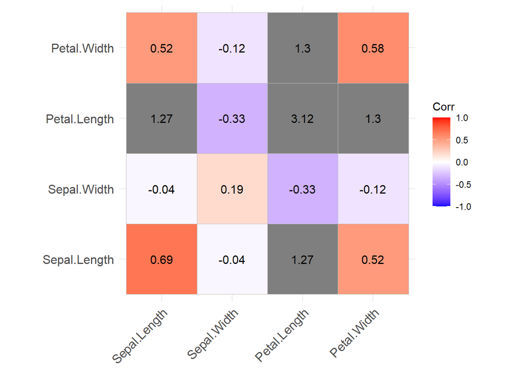

```r
# Matriz de covariância
cov_matrix <- cov(iris[,1:4])

# Plotando a matriz de covariância
ggcorrplot(cov_matrix, lab = TRUE)
```

### Correlação de Pearson

O coeficiente de Pearson mede a relação linear entre duas variáveis quantitativas.

```r
# Coeficiente de correlação de Pearson
cor_pearson <- cor(iris$Sepal.Length, iris$Petal.Length)
print(paste("Correlação de Pearson:", cor_pearson))
```

```
## [1] "Correlação de Pearson: 0.871753775886583"
```

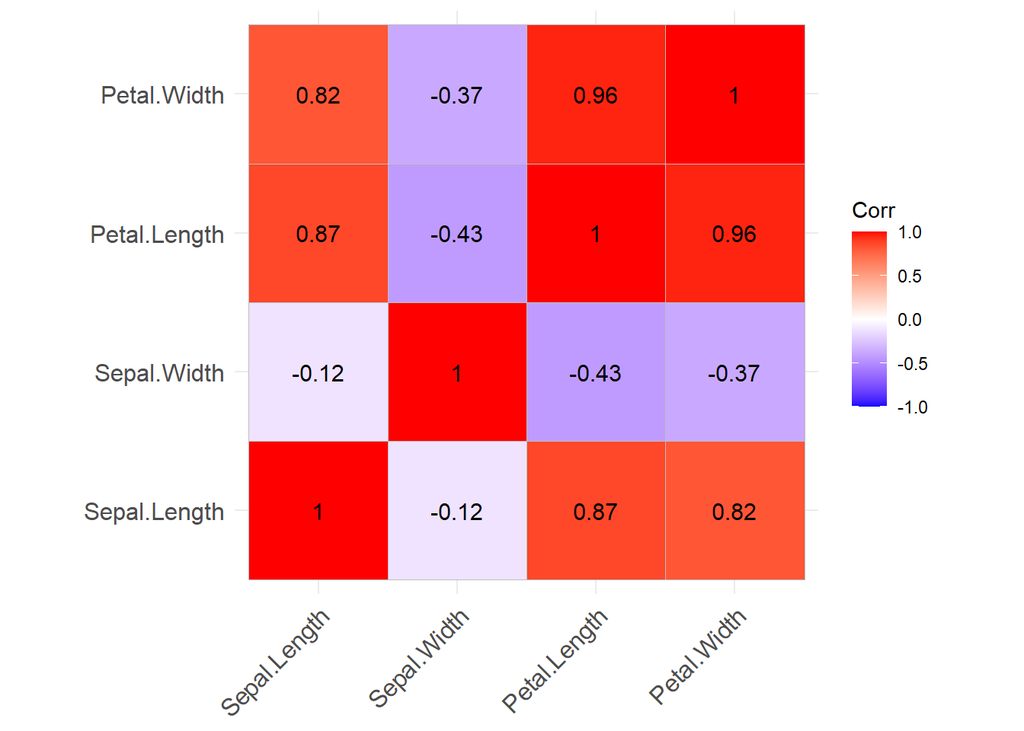

```r
# Matriz de correlação
cor_matrix <- cor(iris[,1:4])

# Plotando a matriz de correlação
ggcorrplot(cor_matrix, lab = TRUE)
```

### Qui-Quadrado

O teste de Qui-Quadrado avalia a associação entre duas variáveis categóricas.

```r
# Teste de Qui-Quadrado
chisq_test <- chisq.test(iris$Species, iris$Species)
print(chisq_test)
```

```
##
##  Pearson's Chi-squared test
##
## data:  iris$Species and iris$Species
## X-squared = 300, df = 4, p-value < 2.2e-16
```

## **Medidas de forma**

As medidas de forma, como assimetria e curtose, são essenciais na estatística descritiva para descrever a distribuição dos dados.

### Assimetria (Skewness)

A assimetria é uma medida que descreve o grau de desvio da simetria em uma distribuição de dados.

```r
#install.packages("e1071")
```

```r
library(e1071)
library(ggplot2)
```

```r
# Gerar dados com diferentes assimetrias
set.seed(12)
dados_simetricos <- rnorm(1000) # Dados simétricos
dados_negativo <- rnorm(1000, mean = 5, sd = 0.5) - abs(rnorm(100)) # Assimetria negativa
dados_positivo <- rnorm(1000, mean = 5, sd = 0.5) + abs(rnorm(100)) # Assimetria positiva
```

```r
# Calcular assimetria
skewness_simetricos <- skewness(dados_simetricos)
skewness_negativo <- skewness(dados_negativo)
skewness_positivo <- skewness(dados_positivo)
```

```r
# Exibir valores de assimetria
print(paste("Assimetria Simétricos:", skewness_simetricos))
```

```
## [1] "Assimetria Simétricos: 0.0232829186697884"
```

```r
print(paste("Assimetria Negativa:", skewness_negativo))
```

```
## [1] "Assimetria Negativa: -0.42033149252098"
```

```r
print(paste("Assimetria Positiva:", skewness_positivo))
```

```
## [1] "Assimetria Positiva: 0.452752436056338"
```

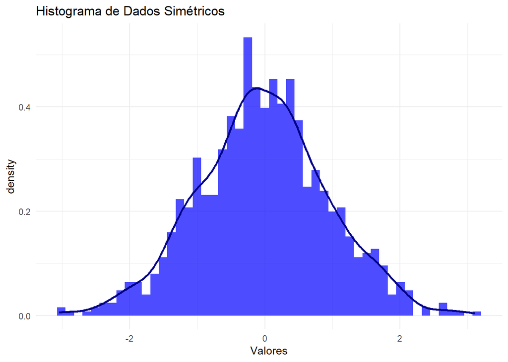

```r
# Histograma para dados simétricos
ggplot(data.frame(Valores = dados_simetricos), aes(x = Valores)) +
  geom_histogram(aes(y = ..density..), bins = 50, fill = "blue", alpha = 0.7) +
  geom_density(color = "darkblue", size = 1) +
  ggtitle("Histograma de Dados Simétricos") +
  theme_minimal()
```

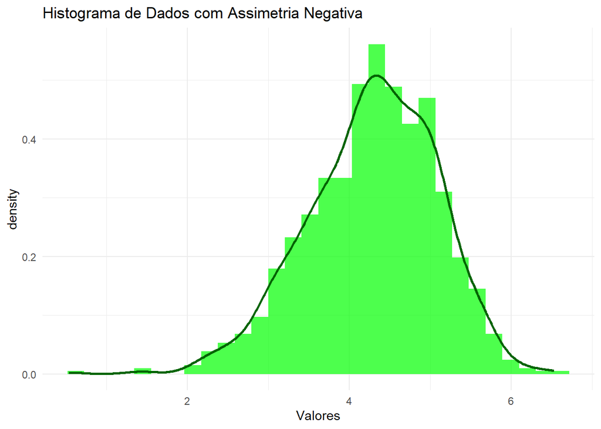

```r
# Histograma para dados com assimetria negativa
ggplot(data.frame(Valores = dados_negativo), aes(x = Valores)) +
  geom_histogram(aes(y = ..density..), bins = 30, fill = "green", alpha = 0.7) +
  geom_density(color = "darkgreen", size = 1) +
  ggtitle("Histograma de Dados com Assimetria Negativa") +
  theme_minimal()
```

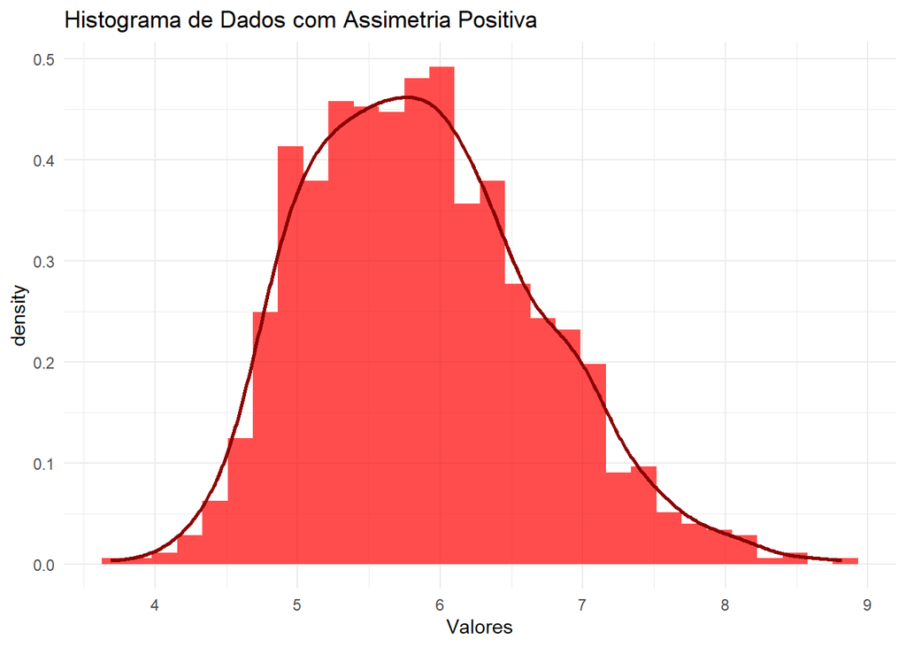

```r
# Histograma para dados com assimetria positiva
ggplot(data.frame(Valores = dados_positivo), aes(x = Valores)) +
  geom_histogram(aes(y = ..density..), bins = 30, fill = "red", alpha = 0.7) +
  geom_density(color = "darkred", size = 1) +
  ggtitle("Histograma de Dados com Assimetria Positiva") +
  theme_minimal()
```

### Curtose (kurtosis)

A curtose é uma medida que descreve a “altura” e “nitidez” do pico central de uma distribuição e a “espessura” das caudas.

```r
#install.packages("devtools")
#install.packages("moments")
```

```r
library(dplyr)
library(plotly)
library(moments)
# Gerar dados com diferentes curtoses
dados_plati <- runif(10000) # Dados platicúrticos
dados_lepto <- rt(1000, df = 3) # Dados leptocúrticos
dados_meso <- rnorm(1000) # Dados mesocúrticos

# Calcular curtose
curtose_plati <- kurtosis(dados_plati)
curtose_lepto <- kurtosis(dados_lepto)
curtose_meso <- kurtosis(dados_meso)

# Exibir valores de curtose
print(paste("Curtose Platicúrtica:", curtose_plati))
```

```
## [1] "Curtose Platicúrtica: 1.77401283444425"
```

```r
print(paste("Curtose Leptocúrtica:", curtose_lepto))
```

```
## [1] "Curtose Leptocúrtica: 8.90147507376246"
```

```r
print(paste("Curtose Mesocúrtica:", curtose_meso))
```

```
## [1] "Curtose Mesocúrtica: 2.99190445595774"
```

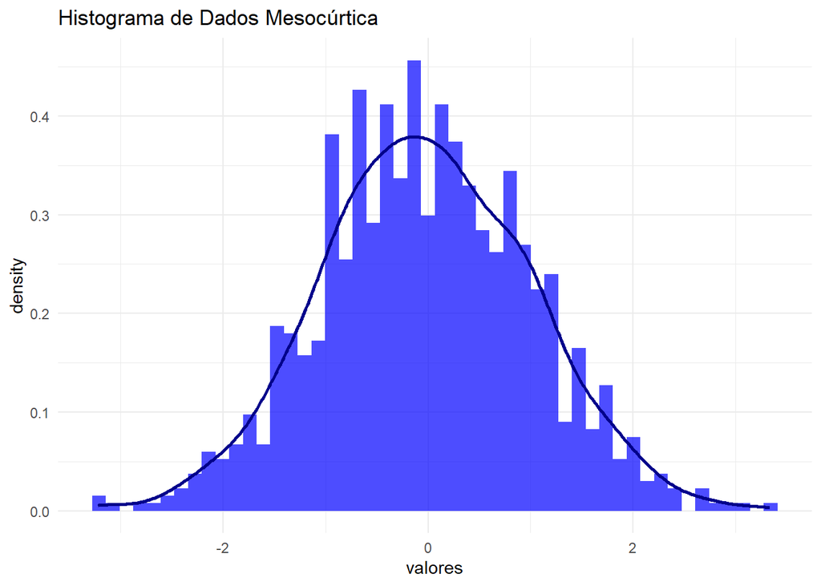

```r
# Histograma para dados Mesocúrtica
ggplot(data.frame(valores = dados_meso), aes(x = valores)) +
  geom_histogram(aes(y = ..density..), bins = 50, fill = "blue", alpha = 0.7) +
  geom_density(color = "darkblue", size = 1) +
  ggtitle("Histograma de Dados Mesocúrtica") +
  theme_minimal()
```

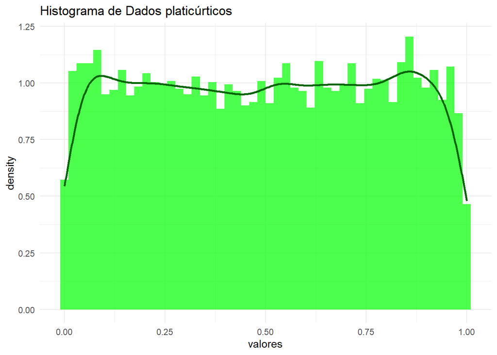

```r
# Histograma para dados platicúrticos
ggplot(data.frame(valores = dados_plati), aes(x = valores))  +
  geom_histogram(aes(y = ..density..), bins = 50, fill = "green", alpha = 0.7) +
  geom_density(color = "darkgreen", size = 1) +
  ggtitle("Histograma de Dados platicúrticos") +
  theme_minimal()
```

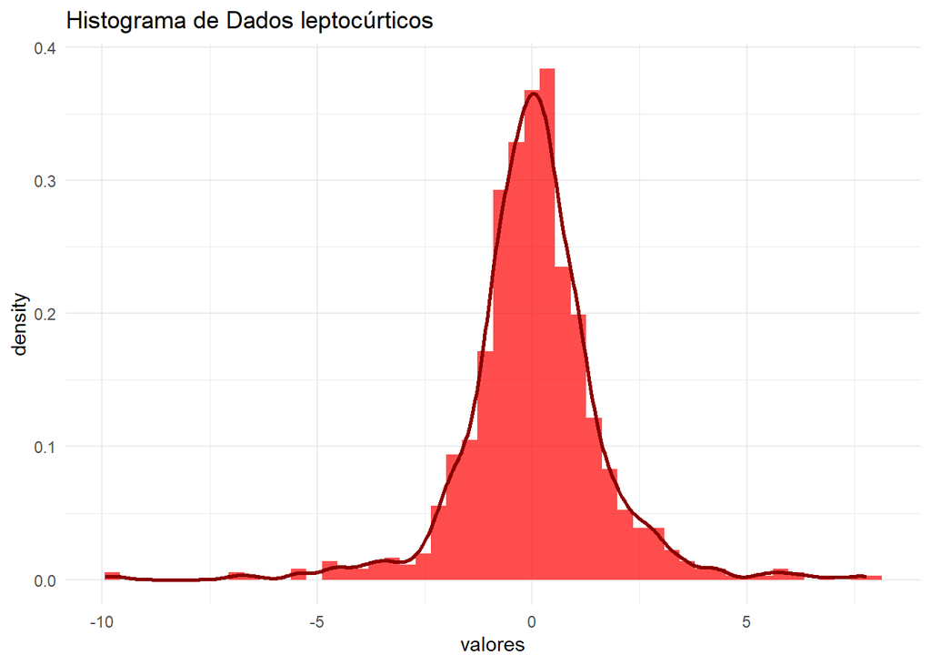

```r
# Histograma para dados leptocúrticos
ggplot(data.frame(valores = dados_lepto), aes(x = valores))  +
  geom_histogram(aes(y = ..density..), bins = 50, fill = "red", alpha = 0.7) +
  geom_density(color = "darkred", size = 1) +
  ggtitle("Histograma de Dados leptocúrticos") +
  theme_minimal()
```

## **Geração de Gráficos**

Sabemos que os gráficos são ferramentas poderosas para visualizar e compreender dados, No R você pode criar cada um dos tipos de gráficos usando ggplot2 e plotly.

```r
# Carregar a bibliotecas
library(ggplot2)
library(plotly)
```

```r
# Converter a tabela de contingência em data.frame
frequencia_df <- as.data.frame(frequencia)
```

```r
# Renomeando colunas
names(frequencia_df) <- c("Categoria", "f_i")
```

### **Gráfico de Barras**

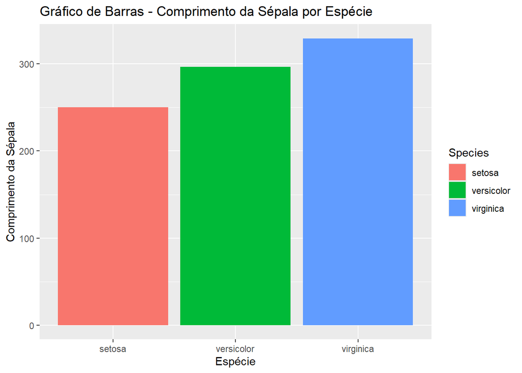

```r
# Gráfico de Barras
ggplot(iris, aes(x = Species, y = Sepal.Length, fill = Species)) +
  geom_bar(stat = "identity") +
  labs(title = "Gráfico de Barras - Comprimento da Sépala por Espécie", x = "Espécie", y = "Comprimento da Sépala")
```

### **Gráfico de Pizza**

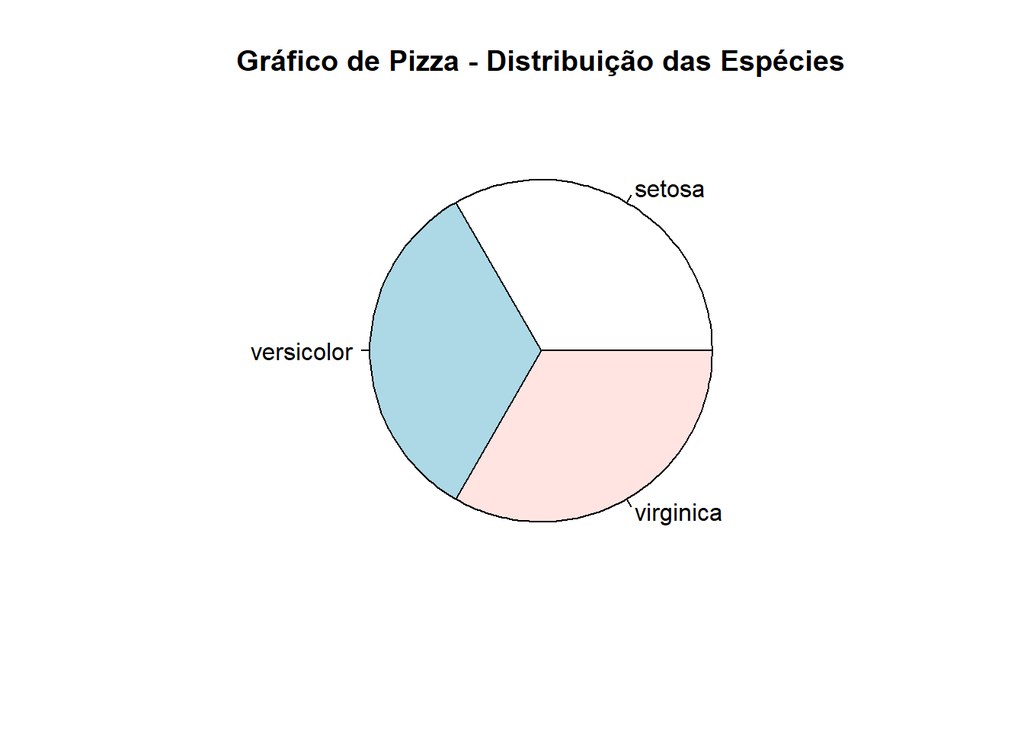

```r
# Gráfico de Pizza
frequencia_iris <- iris %>% count(Species)
pie(frequencia_iris$n, labels = frequencia_iris$Species, main = "Gráfico de Pizza - Distribuição das Espécies")
```

### **Gráfico de Linha**

```r
# Dados de meses e perdas associadas
data <- data.frame(
  Mes = c("January", "February", "March", "April", "May", "June",
          "July", "August", "September", "October", "November", "December"),
  Perdas = c(0.42, 0.38, 0.12, 0.34, 0.22, 0.15, 0.18, 0.31, 0.47, 0.24, 0.42, 0.09)
)
```

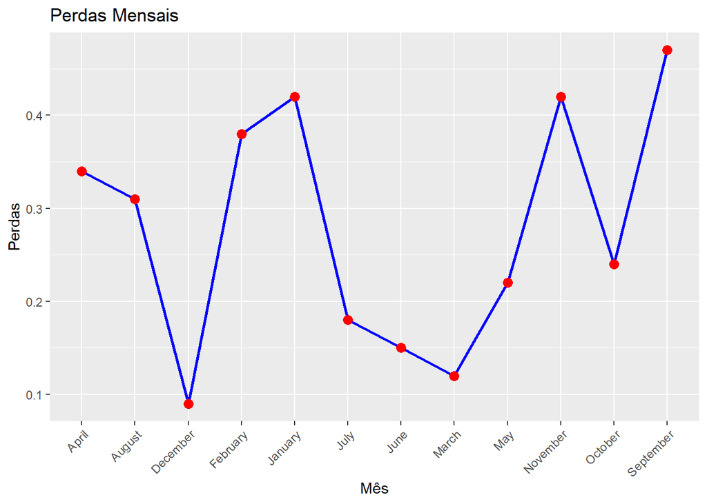

```r
# Criando um gráfico de linhas
ggplot(data, aes(x = Mes, y = Perdas, group = 1))+
  geom_line(color = "blue", size = 1) +
  geom_point(color = "red", size = 3) +
  labs(title = "Perdas Mensais", x = "Mês", y = "Perdas") +
  theme(axis.text.x = element_text(angle = 45, hjust = 1))
```

### **Gráfico de Dispersão**

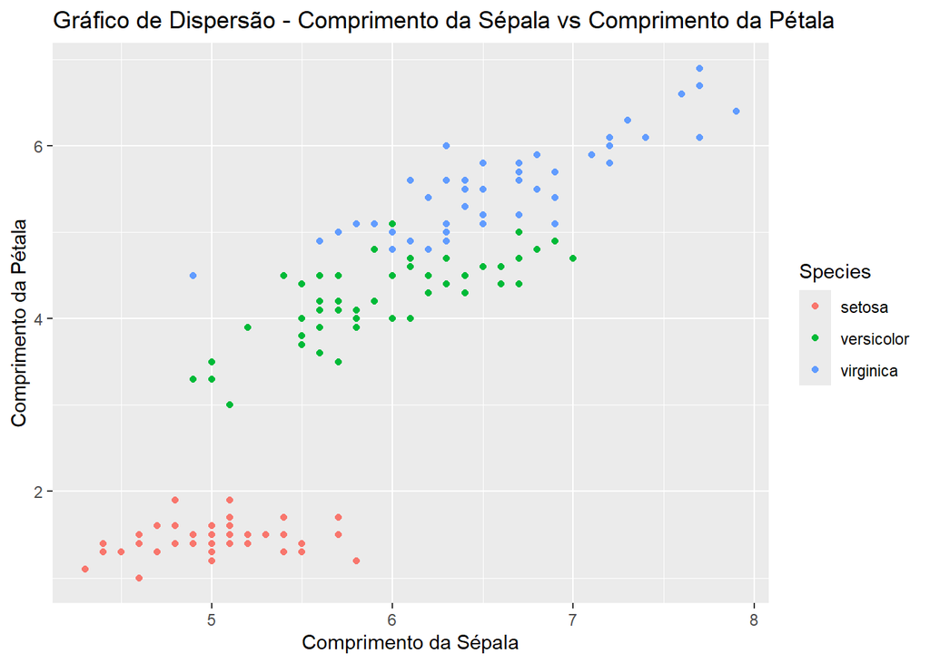

```r
ggplot(iris, aes(x = Sepal.Length, y = Petal.Length, color = Species)) +
  geom_point() +
  labs(title = "Gráfico de Dispersão - Comprimento da Sépala vs Comprimento da Pétala", x = "Comprimento da Sépala", y = "Comprimento da Pétala")
```

### **Sobrepondo gráficos**

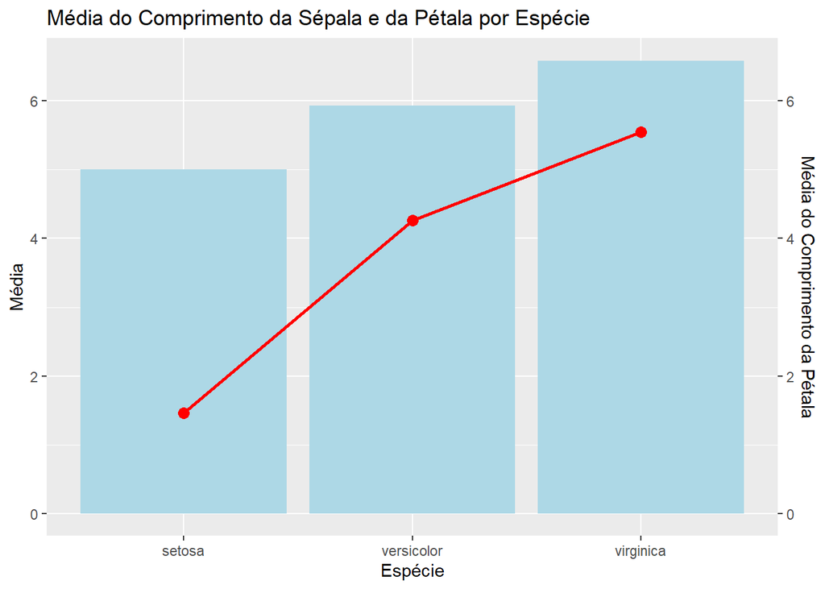

```r
# Calculando as médias para cada espécie
medias <- iris %>%
  group_by(Species) %>%
  summarize(Media_Sepal = mean(Sepal.Length), Media_Petal = mean(Petal.Length))

# Criando o gráfico de barras
ggplot(medias, aes(x = Species, y = Media_Sepal, group = 1)) +
  geom_bar(stat = "identity", fill = "lightblue") +
  labs(title = "Média do Comprimento da Sépala e da Pétala por Espécie", x = "Espécie", y = "Média") +
  # Adicionando o gráfico de linha
  geom_line(aes(y = Media_Petal), color = "red", size = 1) +
  geom_point(aes(y = Media_Petal), color = "red", size = 3) +
  # Adicionando uma legenda secundária para o eixo Y
  scale_y_continuous(sec.axis = sec_axis(~ ., name = "Média do Comprimento da Pétala"))
```

### **Histograma**

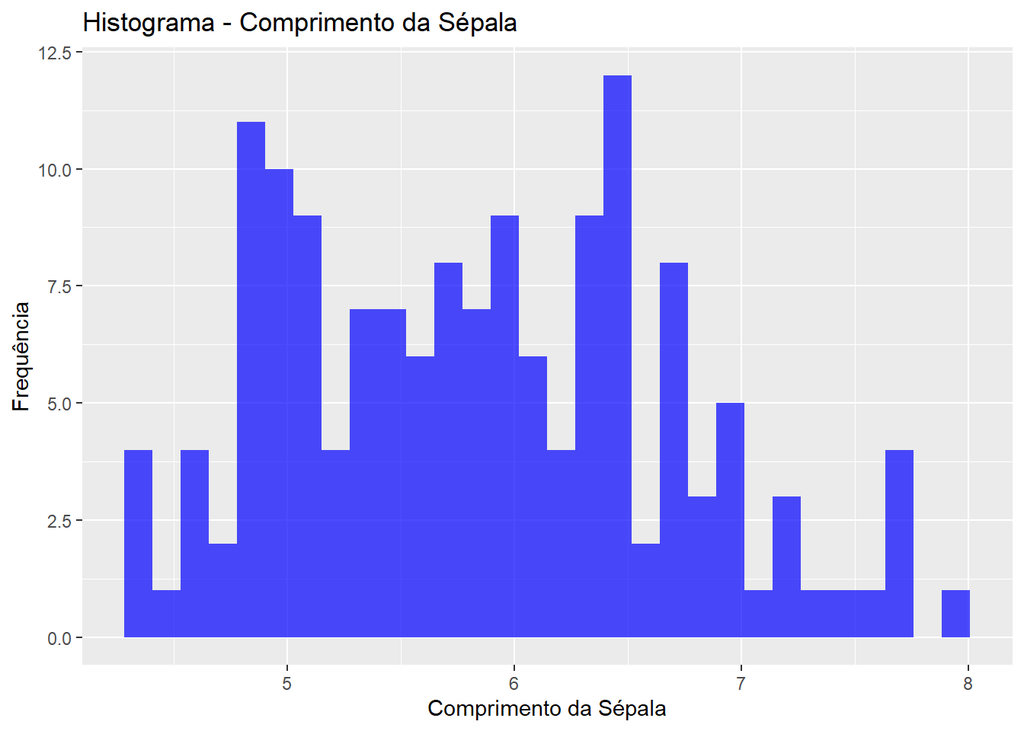

```r
# Histograma
ggplot(iris, aes(x = Sepal.Length)) +
  geom_histogram(bins = 30, fill = "blue", alpha = 0.7) +
  labs(title = "Histograma - Comprimento da Sépala", x = "Comprimento da Sépala", y = "Frequência")
```

### **Boxplot**

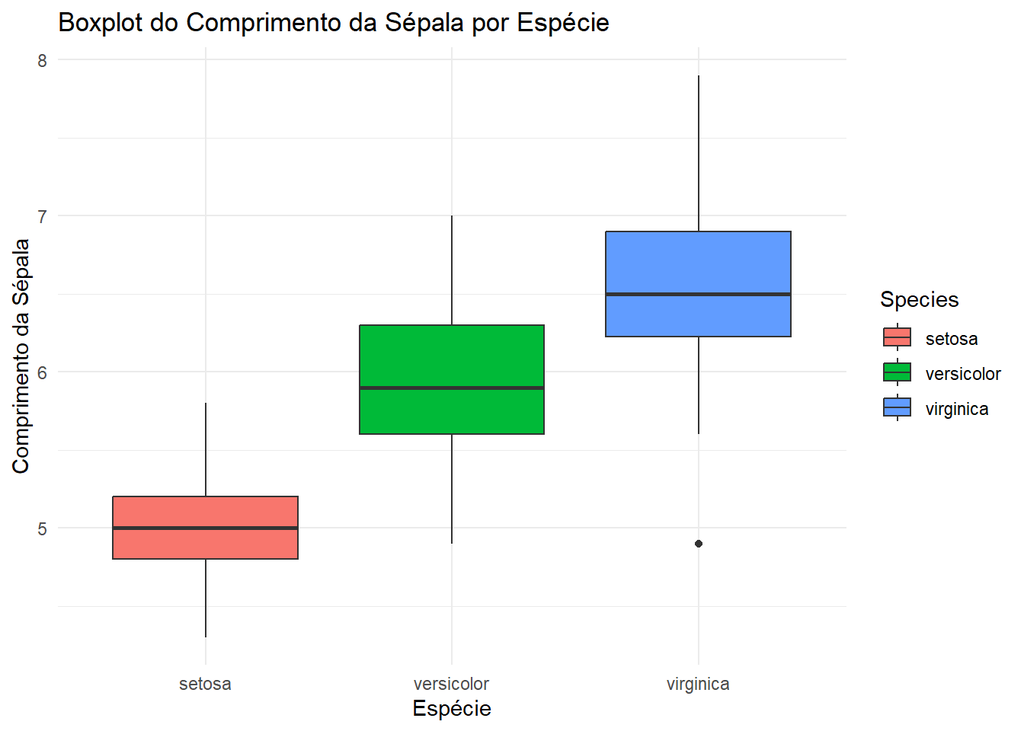

```r
# Criando o boxplot
ggplot(data = iris, aes(x = Species, y = Sepal.Length, fill = Species)) +
  geom_boxplot() +
  labs(title = "Boxplot do Comprimento da Sépala por Espécie", x = "Espécie", y = "Comprimento da Sépala") +
  theme_minimal()
```

## **Estatística Inferencial**

A Estatística Inferencial envolve a análise e interpretação de dados amostrais para fazer inferências sobre uma população maior.

### **Intervalos de Confiança**

Intervalos de confiança oferecem uma faixa de valores prováveis para um parâmetro populacional.

```r
data(mtcars)
head(mtcars)
```

```
##                    mpg cyl disp  hp drat    wt  qsec vs am gear carb
## Mazda RX4         21.0   6  160 110 3.90 2.620 16.46  0  1    4    4
## Mazda RX4 Wag     21.0   6  160 110 3.90 2.875 17.02  0  1    4    4
## Datsun 710        22.8   4  108  93 3.85 2.320 18.61  1  1    4    1
## Hornet 4 Drive    21.4   6  258 110 3.08 3.215 19.44  1  0    3    1
## Hornet Sportabout 18.7   8  360 175 3.15 3.440 17.02  0  0    3    2
## Valiant           18.1   6  225 105 2.76 3.460 20.22  1  0    3    1
```

Calcular média e desvio padrão da milhagem por galão (mpg)

```r
mean_mpg <- mean(mtcars$mpg)
std_mpg <- sd(mtcars$mpg)

print(mean_mpg)
```

```
## [1] 20.09062
```

```r
print(std_mpg)
```

```
## [1] 6.026948
```

```r
# Calcular intervalo de confiança para a média de mpg
conf_interval <- t.test(mtcars$mpg)$conf.int
print(conf_interval)
```

```
## [1] 17.91768 22.26357
## attr(,"conf.level")
## [1] 0.95
```

### **Testes de Hipóteses**

Testes de hipóteses são utilizados para tomar decisões estatísticas com base em dados amostrais.

```r
# Separar dados em dois grupos
manual <- mtcars %>% filter(am == 1) %>% .$mpg
automatic <- mtcars %>% filter(am == 0) %>% .$mpg
```

```r
# Teste t para comparar a média de mpg entre carros manuais e automáticos
t_result <- t.test(manual, automatic)
print(t_result)
```

```
##
##  Welch Two Sample t-test
##
## data:  manual and automatic
## t = 3.7671, df = 18.332, p-value = 0.001374
## alternative hypothesis: true difference in means is not equal to 0
## 95 percent confidence interval:
##   3.209684 11.280194
## sample estimates:
## mean of x mean of y
##  24.39231  17.14737
```